# Pós-graduação em Ciências Veterinárias (IV/UFRRJ)

Análise Exploratória de Dados (AED) - Uma Revisão

Adriana Andrade Wagner Tassinari

2021

[figure not shown]

# Modelo de Regressão Linear Simples (MRLS)

O Modelo de regressão linear simples (MRLS) expressa a relação entre duas variáveis quantitativas $X$ e $Y$ , de modo que se obtenha o valor esperado de $Y$ para cada valor de $X$, ou seja, $E(Y|x)$.

Essa técnica possibilita estimar a magnitude do efeito de $X$ em $Y$ a partir de uma função linear:

$$Y_i=\beta_{0}+\beta_{1}X_i+\varepsilon_i$$

Onde:

- $\beta_{0}$ - intercepto do modelo. Geralmente, não é interpretado. Representa o valor esperado de $Y$ quando $X = 0$;
- $\beta_{1}$ - representa o acréscimo esperado na variável resposta quando a variável explicativa é acrescida de uma unidade;
- $\varepsilon_i$ – erro aleatório. Esse termo representa os fatores não incluídos no modelo que, de alguma forma, causam variação em $Y$, ou seja, corresponde a variação em $Y$ que não é causada por $X$.

# Estrutura do MRLS

O MRLS pode ter sua forma divida em duas partes:

- Parte Sistemática: $\beta_{0}+\beta_{1}X_i$
- Parte Aleatória: $\varepsilon_i$

## Parte Sistemática do modelo

A componente sistemática, que pode ser interpretada geometricamente como uma reta em função de $X$, representa a informação sobre $Y$ que poderíamos esperar apenas com o conhecimento da variável $X$.

O valor de $\beta_1$ é o tamanho do grau de inclinação da reta de regressão e representa a variação na média de $Y$ dado um valor de $x$.

Quanto maior for o seu valor em módulo, maior será a inclinação da reta e, portanto, maior será o efeito de $X$ em relação a $Y$.

A cada unidade de variação em $X$, observa-se um aumento ou uma diminuição no valor de $Y$ na ordem de $\beta_1x$.

## Parte Aleatória do modelo

O uso de dados provenientes de amostras aleatórias introduz uma aleatoriedade nas informações coletadas que irá repercutir no ajuste do modelo de regressão. Assim sendo, ocorrerão afastamentos entre os valores observados $y_i$ e os valores preditos pelo modelo $\hat{y}_i$.

Essa distância entre $y_i$ e $\hat{y}_i$ é denominada de resíduo $e_i$.

Portanto os resíduos do MRLS que expressam a diferença entre os valores observados e os valores ajustados são obtidos por:

$$e_i = y_i-\hat{y}_i = y_i - (\hat{\beta_0}+\hat{\beta}_1 X_i)$$

**Propriedades do termo de erro do MRLS**

- A média dos erros é nula, isto é, $E(\varepsilon_i) = 0$;
- $\varepsilon_i \sim N(0,\sigma^2)$, portanto a $Var(\varepsilon_i)$ não se altera de acordo com valores específicos de $X$. Diz-se, então, que o erro é homocedástico;
- Assume-se que os erros aleatórios correspondentes às observações são variáveis aleatórias não correlacionadas, ou seja: $Cov(\varepsilon_i,\varepsilon_j) = 0$ para $i \neq j$.

# Prática

- Base de dados: daisy2.xlsx
- Conjunto de dados proveniente de um estudo tipo coorte a respeito das condições do manejo reprodutivo em rebanhos de bovinos leiteiros. O objetivo é avaliar o desempenho reprodutivo e a produção de leite desses animais.

# Preparando o banco de dados

- Abra o banco de dados:

```r
library(readxl)
daisy2 <- read_excel("G:/Meu Drive/Projects/MLG_2021/Bancos/daisy2.xlsx")

daisy2 <- daisy2[daisy2$h7 == 1, ] # vamos apenas usar um subconjunto dos dados

head(daisy2)
```

```
# A tibble: 6 x 19
  region  herd   cow study_lact herd_size   mwp parity milk120 calv_dt    cf
   <dbl> <dbl> <dbl>      <dbl>     <dbl> <dbl>  <dbl>   <dbl>   <dbl> <dbl>
1      1     1     1          1       294    26      5   3506.   13464    80
2      1     1     2          1       294    26      5   3691.   13526    64
3      1     1     3          1       294    26      5   4173    13531    71
4      1     1     4          1       294    26      5   3727.   13556    35
5      1     1     5          1       294    26      5   3091.   13691    47
6      1     1     6          1       294    26      4   5041.   13438    NA
# ... with 9 more variables: fs <dbl>, cc <dbl>, wpc <dbl>, spc <dbl>,
#   twin <dbl>, dyst <dbl>, rp <dbl>, vag_disch <dbl>, h7 <dbl>
```

Ou siga as seguintes etapas no RStudio: *Environment –> Import Dataset –> From Excel…*

- Selecione as variáveis para compor o banco que será trabalhado
  - *cow* - Identificador do animal
  - *milk120* - Litros de leite nos primeiros 120 dias de lactação
  - *parity* - Número de partos
  - *mwp* - Intervalo do período de espera até a concepção
  - *twin* - Nascimento duplo

```r
#Seleção das variáveis que irão compor a base de dados
library(tidyverse)

banco <- daisy2 %>%
  select (cow, milk120,parity,mwp,dyst,twin)
View(banco)
```

## Verificação de valores ausentes

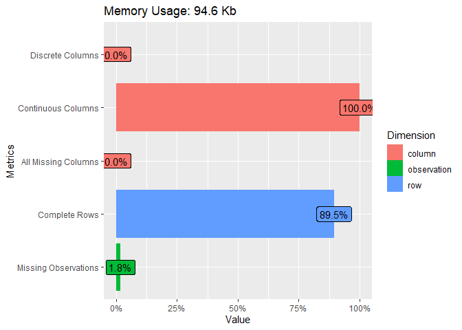

```r
#Verificação de Missing values na base de dados

library(DataExplorer)

plot_intro(banco)
```

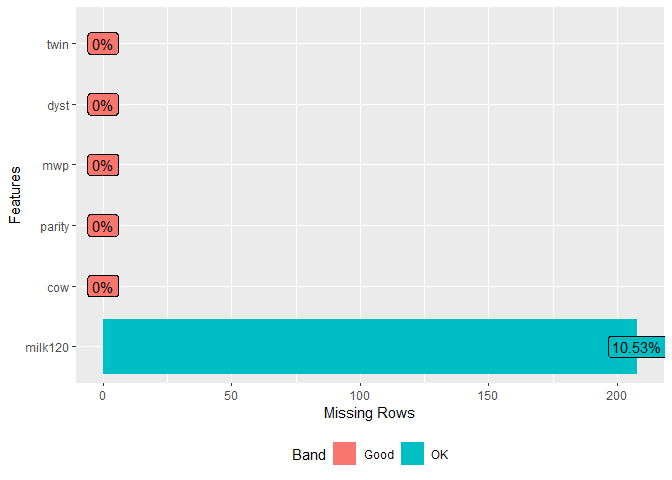

```r
plot_missing(banco)
```

```r
introduce(banco$milk120)
```

```
                rows              columns     discrete_columns
                1976                    1                    0
  continuous_columns  all_missing_columns total_missing_values
                   1                    0                  208
       complete_rows   total_observations         memory_usage
                1768                 1976                16960
```

## Tratamento dos Valores Ausentes

Iremos excluir os valores ausentes da base sob análise pelo fato de se tratar de um exercício. Em geral, esse recurso deve ser o último a ser adotado. Uma maneira de tatar os valores ausentes é o uso de algum método de imputação.

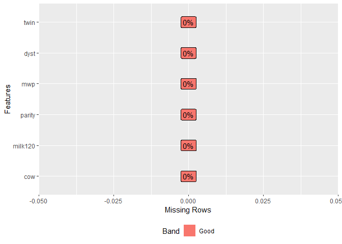

```r
banco<-banco %>%
  drop_na(milk120)

plot_missing(banco)
```

# Ajuste do Modelo

Vamos supor que estamos interessados em estudar a relação entre **a quantidade de leite produzida nos primeiros 120 dias de lactação** em relação ao **número de partos**.

**Avaliação da Correlação entre as variáveis**

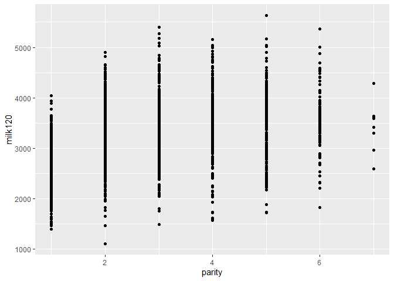

```r
ggplot (data=banco, aes(parity,milk120))+
  geom_point()
```

```r
cor(banco$parity,banco$milk120)
```

```
[1] 0.3810661
```

# Estimação dos Parâmetros do MRLS

A estimação dos parâmetros $\beta_0$ e $\beta_1$ do MRLS, geralmente, é realizada pelo Método dos Mínimos Quadrados (MMQ) que se baseia na ideia de que a soma dos quadrados das distâncias de cada valor observado $y_i$ em relação seu correspondente $\hat{y}_i$ na reta estimada deve ser mínima.

O método dos Mínimos Quadrados busca encontrar estimadores de $\beta_0$ e $\beta_1$ que minimizam a soma dos quadrados dos resíduos.

Seja $\displaystyle L = \sum_{i=1}^n{e_i^2} = \sum_{i=1}^n{\left(y_i- ({\beta_0}+{\beta_1}x_i)\right)^2} = \sum_{i=1}^n{\left(y_i- {\beta_0}-{\beta_1}x_i\right)^2}$

De forma que as estimativas dos coeficientes são fornecidadas pelas expressões:

$\hat{\beta}_1= \frac{\sum_{i=1}^{n}(x_i-\bar{x})(y_i-\bar{y})}{\sum_{i=1}^{n}(x_i-\bar{x})^2} = \frac{ \sum_{i=1}^{n}x_iy_i - n\bar{x}\bar{y}}{\sum_{i=1}^{n} x^2_i - n\bar{x}^2}$

$\hat{\beta}_0=\bar{y}+\hat{\beta}_1\bar{x}$

**Estimação dos Parâmetros**

```r
mrls<-lm(banco$milk120~banco$parity)

mrls
```

```
Call:
lm(formula = banco$milk120 ~ banco$parity)

Coefficients:
 (Intercept)  banco$parity
      2733.9         171.6
```

**Modelo ajustado**: $\hat{y}_i = 2733,9 + 171,6x_i$

onde:

$\hat{y}_i$ representa a variável produtividade de leite

$x_i$ o número de partos.

O coeficiente estimado $\hat{\beta}_0 = 2733,9$ indica que em média, há uma produtividade de 2733,9 litros quando não há parto.

O coeficiente estimado $\hat{\beta}_1 = 171,6$ indica que a cada parto, observa-se um aumento de 171,6 litros na produção de leite.

# Inferência para os parâmetros do modelo

No contexto do MRLS, o teste de hipótese está relacionado com a significância da regressão, ou seja, implica testar a existência de relação linear entre $X$ e $Y$. Esse teste é realizado a partir da significância da estimativa do parâmetro de inclinação $\beta_1$.

## Teste de Hipóteses na Regressão Linear Simples

Hipóteses:

$H_0:\beta_1 = 0$

$H_1:\beta_1 \neq 0$

O teste de hipótese para o parâmetro de inclinação $\beta_1$ verifica a importância da contribuição da variável regressora $X$ na explicação da variação da variável resposta $Y$. Se $H_0$ for verdadeira, isto é, $\beta_1$ = 0, essa contribuição não é significativa ou a verdadeira relação entre $x$ e $Y$ não é linear.

## Estatística de Teste

A estatística de teste parâmetro $\beta_1$ é dada por:

$T=\frac{\hat{\beta_1}}{\sqrt{\frac{\hat{\sigma^2}}{S_{XX}}}}\sim t_{(n-2)}$, sob $H_0$

```r
summary(mrls)
```

```
Call:
lm(formula = banco$milk120 ~ banco$parity)

Residuals:
     Min       1Q   Median       3Q      Max
-1966.89  -433.40   -14.28   424.68  2151.20

Coefficients:
             Estimate Std. Error t value Pr(>|t|)
(Intercept)  2733.862     32.317   84.60   <2e-16 ***
banco$parity  171.614      9.908   17.32   <2e-16 ***
---
Signif. codes:  0 '***' 0.001 '**' 0.01 '*' 0.05 '.' 0.1 ' ' 1

Residual standard error: 650.5 on 1766 degrees of freedom
Multiple R-squared:  0.1452,    Adjusted R-squared:  0.1447
F-statistic:   300 on 1 and 1766 DF,  p-value: < 2.2e-16
```

## Intervalo de Confiança para $\beta_0$ e $\beta_1$

Além das estimativas pontuais de $\beta_0$ e de $\beta_1$, é possível obter estimativas intervalares para esses parâmetros com base em suas distribuições de probabilidade.

A amplitude desses intervalos revela informações sobre a qualidade geral da reta de regressão.

Rejeita-se $H_0$ quando o intervalo de confiança estimado não contiver o zero.

```r
confint(mrls)
```

```
                 2.5 %    97.5 %
(Intercept)  2670.4790 2797.2453
banco$parity  152.1813  191.0466
```

# Predição

## Valores Preditos

Um dos principais objetivos da estimação de um modelo de regressão linear é obter estimativas para a variável resposta $Y$ considerando os valores da variável regressora $X$.

Uma vez que os coeficientes $\beta_0$ e $\beta_1$ foram estimados, basta colocar um valor específico de $x$ na equação do modelo obtida para calcular o valor de $\hat{y}_i$ predito pelo modelo.

O modelo obtido para o exemplo que relaciona o aumento da produção de leite com o número de partos possui a seguinte equação:

$\hat{y}_i = 2733,9 + 171,6x_i$

Com base nesse modelo, podemos obter a média de produção de leite para os animais que tiveram 2 partos por $\hat{y}(2,0)$:

$\hat{y}(2) = 2733.9 + 171.6(2,0) = 3077.1$

```r
#Obtenção dos valores preditos pelo modelo
y_pred<-fitted(mrls)

valores_y<-cbind(banco$milk120,fitted(mrls))
colnames(valores_y)<-c("y_obs","y_pred")
head(valores_y)
```

```
   y_obs   y_pred
1 3505.8 3591.932
2 3691.3 3591.932
3 4173.0 3591.932
4 3727.3 3591.932
5 3090.8 3591.932
6 5041.2 3420.318
```

## Intervalo de Confiança para Resposta Média

Após o ajuste de um MRLS, é possível obter Intervalos de Confiança para a resposta média $E(Y|x=x_j) = \mu_j$.

Esse intervalo de confiança fornece informação sobre a precisão das estimativas, no sentido de que quanto menor for a amplitude do intervalo, maior será a precisão da estimativa.

O intervalo de confiança para a resposta média de $Y$ será calculado tendo por referência um valor fixo de $x$. Tal que:

$E(Y|x) = \mu_{Y|x} = \beta_0 + \beta_1x$

Podemos obter um intervalo de confiança para a média de produção de leite para os animais que tiveram 2 partos, denotado por:

$IC(\hat{\mu}_{Y|x}=2;0,95)= (3.042,42;3.111,77)$

Com base no cálculo de intervalos de confiança para diferentes valores de $x$, é possível a obtenção de limites de confiança para cada valor de $\mu_{Y|x}$ e, desse modo, a construção de uma região em torno da reta estimada com a indicação dos limites superiores e inferiores desses intervalos.

Essa região é chamada de banda de confiança.

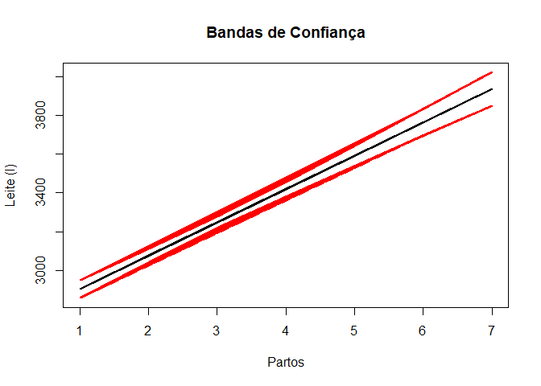

```r
#Intervalo de confiança para a resposta média
conf<-predict(mrls,interval="confidence")

#Gráfico com bandas de confiança
 matplot(banco$parity,
 conf,
 lwd=2.5,
 type="l",
 lty = c(1,2,2),
 col = c("black","red","red"),
 xlab = "Partos",
 ylab="Leite (l)",
 main="Bandas de Confiança")
```

# A abordagem da Análise de Variância para testar a significância de regressão

A análise da variância é uma outra forma de avaliar a significância da regressão, nesse contexto, passa a ser denominada de ANOVA da regressão.

Esse método consiste em decompor a variabilidade total da variável resposta $Y$.

**Identidade da Análise da Variância:**

$$SQT = SQR + SQE$$

**SQT** = $\sum_{i=1}^{n}(y_i-\bar{y})^2$: representa a variabilidade dos valores de $Y$ ao redor da sua média. Denominada de Soma de Quadrados Total;

**SQR** = $\sum_{i=1}^{n}(\hat{y_i}-\bar{y})^2$: representa a quantidade de variabilidade em $Y$ explicada pela reta de regressão. Denominada de Soma de Quadrados da Regressão;

**SQE**= $\sum_{i=1}^{n}(y_i-\hat{y_i})^2$: representa a variação residual não explicada pela reta de regressão. Denominada de Soma de Quadrados do Erro.

$$\sum_{i=1}^{n}(y_i-\bar{y})^2 = \sum_{i=1}^{n}(\hat{y_i}-\bar{y})^2 + \sum_{i=1}^{n}(y_i-\hat{y_i})^2$$

Com base nessas informações é possível construir a tabela da análise da variância – ANOVA (ANalysis Of VAriance) com os valores necessários para realização da estatística de teste. De acordo com a identidade da ANOVA, temos que:

| Fonte de Variação | Gl | SQ | $QM$ | $F_0$ |
| --- | --- | --- | --- | --- |
| Regressão | 1 | $SQR$ | $QMR$ | $\frac{QMR}{QME}$ |
| Erro | $n-2$ | $SQE$ | $QME/(n-2)$ | $-$ |
| Total | $n-1$ | $SQT$ | $-$ | $-$ |

A tabela da ANOVA fornece o valor da estatística de teste $F_0$ relacionada as seguintes hipóteses:

$H_0: \beta_1 = 0$

$H_1: \beta_1\neq 0$

Rejeita-se $H_0$ se $F_0 > F_{\alpha,1,n-2}$.

Um outro modo pelo qual é possível realizar a rejeição de $H_0$ ocorre quando o $valor-p$ for muito pequeno.

```r
#Obtenção da Tabela da ANOVA
anova(mrls)
```

```
Analysis of Variance Table

Response: banco$milk120
               Df    Sum Sq   Mean Sq F value    Pr(>F)
banco$parity    1 126939726 126939726  300.01 < 2.2e-16 ***
Residuals    1766 747232213    423121
---
Signif. codes:  0 '***' 0.001 '**' 0.01 '*' 0.05 '.' 0.1 ' ' 1
```

De acordo com os dados da tabela ANOVA, percebemos que o modelo de regressão com a variável número de lactações corresponde a uma redução na ordem de $126.939.726$ da soma de quadrados total que é igual a $874.171.939$.

O valor assumido pela estatística $F$ com base no valor $p$ é bem inferior ao nível de significância de $0,1\%$, o que nos permite concluir pela significância do modelo baseado na número de partos para predizer o aumento em litros de leite nos primeiros 120 dias de lactação.

# Qualidade do Ajuste

A $SQE$ fornece uma medida de qualidade do ajuste do MRLS, pois quanto menor for essa quantidade melhor será o ajuste do modelo aos valores observados.

**Coeficiente de Determinação**

O Coeficiente de Determinação $(R^2)$ é uma medida obtida pela comparação entre a $SQR$ e $SQT$ que possibilita a avaliação da qualidade de ajuste do modelo, bem como possibilita a comparação entre modelos.

$R^2 = \rho^2 =\frac{SQR}{SQT} = \frac{\sum_{i=1}^{n}(\hat{y_i}-\bar{y})}{\sum_{i=1}^{n}(y_i-\bar{y})}$

O valor de $R^2$, geralmente, é interpretado como a quantidade de variação nos dados explicada pelo modelo de regressão. Assim sendo, quando o valor de $R^2$ for próximo de zero, o modelo de regressão não é adequado. Caso $R^2$ reporte um valor próximo a um, o modelo de regressão pode ser adequado.

```r
#Coeficiente de Determinação

summary(mrls)
```

```
Call:
lm(formula = banco$milk120 ~ banco$parity)

Residuals:
     Min       1Q   Median       3Q      Max
-1966.89  -433.40   -14.28   424.68  2151.20

Coefficients:
             Estimate Std. Error t value Pr(>|t|)
(Intercept)  2733.862     32.317   84.60   <2e-16 ***
banco$parity  171.614      9.908   17.32   <2e-16 ***
---
Signif. codes:  0 '***' 0.001 '**' 0.01 '*' 0.05 '.' 0.1 ' ' 1

Residual standard error: 650.5 on 1766 degrees of freedom
Multiple R-squared:  0.1452,    Adjusted R-squared:  0.1447
F-statistic:   300 on 1 and 1766 DF,  p-value: < 2.2e-16
```

# Adequação do Ajuste

Após a realização do ajuste do modelo com a estimação dos parâmetros de interesse e a realização dos testes de hipóteses, a próxima etapa da modelagem diz respeito à verificação dos pressupostos relacionados a esse ajuste.

**Análise da Violação das Suposições**

Serão verificadas as seguintes suposições básicas do MRLS:

- Relação linear entre as variáveis $X$ e $Y$;
- Normalidade de $e_i$, $i = 1, 2, ..., n$;
- Homocedasticidade das variâncias de $e_i$;
- Independência das variáveis de erro.

Essa etapa de adequação do modelo é realizada com a análise dos resíduos.

**Estimação dos Resíduos**

Uma vez obtidos os valores de $\hat{\beta_0}$ e $\hat{\beta_1}$ , pode-se calcular uma estimativa para os resíduos do modelo.

**Resíduos ordinários**

Os resíduos do processo de ajuste por mínimos quadrados são dados por:

$e_i = \hat{\varepsilon_i} = y_i - \hat{y_i}$

**Resíduos padronizados**

O objetivo dessa transformação reside em obter uma variável aleatória com esperança igual a zero e desvio padrão igual a um.

O resíduo padronizado é obtido pela divisão dos resíduos $(e_i)$ pela raiz quadrada do quadrado médio do erro (QME).

$d_i = \frac{e_i}{\sqrt{QME}} = \frac{e_i}{\sqrt{\hat{\sigma^2}}}$

```r
#resíduos ordinários
r<-mrls$residuals

#resíduos padronizados
rp<-rstandard(mrls)

#Visualização dos resíduos
residuos <- cbind(r,rp)

head(residuos)
```

```
           r         rp
1  -86.13201 -0.1325211
2   99.36799  0.1528858
3  581.06794  0.8940206
4  135.36799  0.2082747
5 -501.13201 -0.7710326
6 1620.88211  2.4929119
```

## Análise Gráfica dos Resíduos

**1 - Boxplot dos Resíduos**

Possibilita a verificação da suposição da normalidade dos erros e a identificação de outliers.

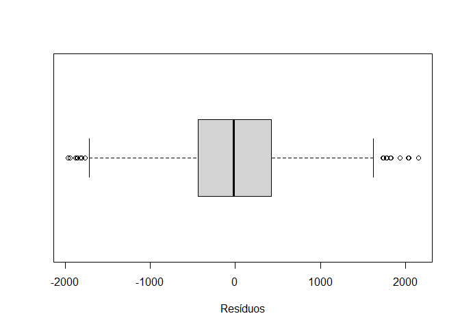

```r
#Boxplot dos resíduos
boxplot(mrls$residuals,xlab="Resíduos", horizontal = T)
```

**2 - Gráficos normal de probabilidades (QQnorm)**

No gráfico QQnorm dos resíduos de um ajuste adequado, os pontos estão alinhados na reta que representa a identidade dos quantis amostrais e teóricos. Afastamentos desse padrão evidencia que os resíduos não estão normalmente distribuídos.

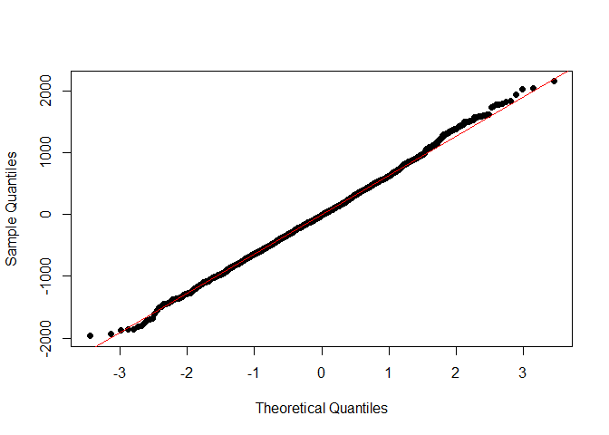

```r
#QQNorm dos resíduos
qqnorm(mrls$residuals,pch=19, main = "")
qqline(mrls$residuals,col="red")
```

**3 - Diagramas de Dispersão da variável explicativa vs resíduos**

Avaliação da linearidade entre X e Y e detectar prováveis valores atípicos.

O padrão para esse tipo de gráfico é uma distribuição aleatória de média 0 e amplitude constante. Desvios sistemáticos podem indicar não-linearidade entre X e Y (formato de parábola, ou algum formato que indique a necessidade de alguma transformação ou adição de termo de quadrático ou de grau superior).

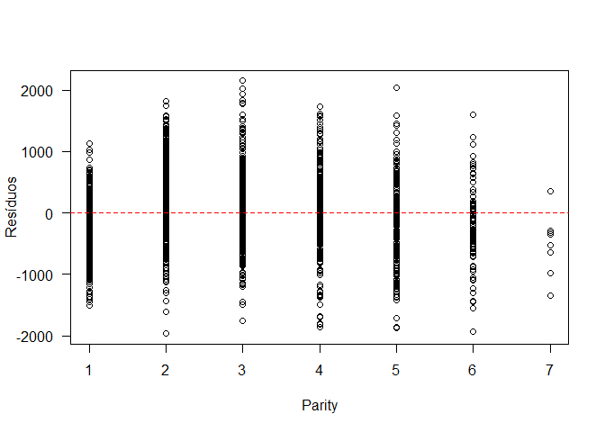

```r
#Linearidade entre X e Y

plot(banco$parity,mrls$residuals,xlab="Parity",ylab="Resíduos",main="",
las=1)
abline(h=0, lwd=1, lty=2, col="red")
```

**4 - Diagramas de Dispersão dos valores preditos vs Resíduos**

Possibilita verificar suposições de violação da homocedasticidade das variâncias. No caso da regressão linear simples, esse gráfico é equivalente ao gráfico da variável explicativa versus os resíduos.

O padrão para esse tipo de gráfico é uma distribuição aleatória de média 0 e amplitude constante. Desvios sistemáticos podem indicar heterogeneidade de variâncias (exemplo:formato de “megafone”).

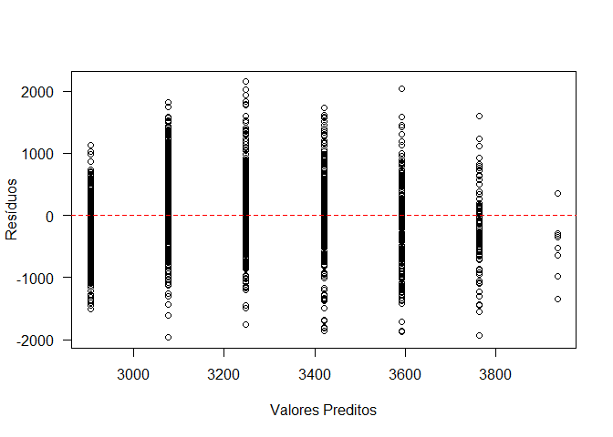

```r
#Homocedasticidade dos Resíduos

##Grafico do predito x residuo
plot(mrls$fitted.values,r,xlab="Valores Preditos",ylab="Resíduos",main="",
las=1)
abline(h=0, lwd=1, lty=2, col="red")
```

**5 - Gráficos de Análise de Resíduos do R**

No R existe a possibilidade de obtenção de um conjunto de gráficos de análise dos resíduos.

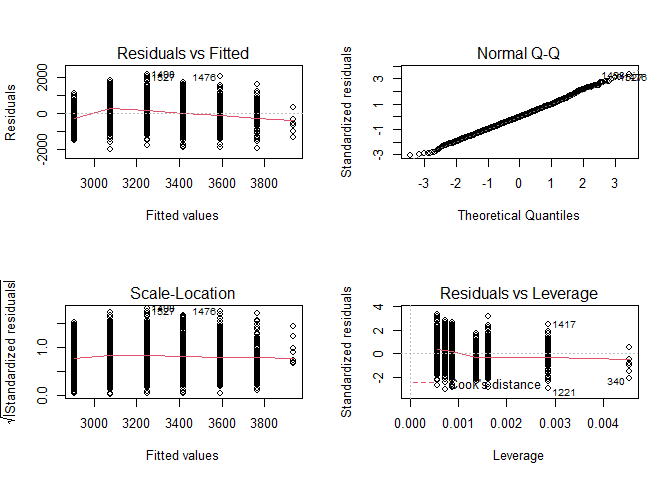

```r
par(mfrow=c(2,2))
plot(mrls)
```

Os dois primeiros gráficos foram obtidos nas análises precedentes.

O terceiro gráfico denominado de *Scale-Location* apresenta os valores ajustados versus a raiz quadrada dos resíduos padronizados. Devemos observar se a linha vermelha é aproximadamente horizontal, o que representa que a média dos resíduos não se altera com os valores ajustados. Além disso, devemos observar como se dá o espalhamento dos resíduos ao redor da reta vermelha. A variação deve ser constante e não aparecer em função dos valores preditos.

O quarto gráfico apresenta as medidas de *leverage*(alavanca) versus os resíduos padronizados. Ele permite avaliar o potencial de influência de uma observação nos parâmetros do modelo a partir do cálculo do $h_i$, medida de importância de uma observação no ajuste do modelo.

Distância de Cook Ajuda a descobrir possíveis outliers. Quantifica o peso da observação no modelo, com uma medida da mudança dos coeficientes de regressão,quando se retira do modelo essa observação.Valores acima de 1 são considerados suspeitos e maiores que 2 sinalizam que o valor é atípico.

## Testes de Hipotes para os resíduos

**1 - Teste de Shapiro-Wilk**

$H_0$: a amostra provém de uma população normalmente distribuída

**2 - Teste de Breusch-Pagan**

$H_0$: a variância dos resíduos é consntate, $var(\varepsilon_i)=\sigma^2$

```r
#Teste de Shapiro-Wilk
shapiro.test(r)
```

```
    Shapiro-Wilk normality test

data:  r
W = 0.99837, p-value = 0.08398
```

```r
#Teste de Breusch-Pagan
#install.packages("lmtest")
library(lmtest)
bptest(mrls)
```

```
    studentized Breusch-Pagan test

data:  mrls
BP = 5.9834, df = 1, p-value = 0.01444
```

# Transformação

Tendo constatado a violação de alguma suposição na etapa de Análise de Resíduos, existe a possibilidade de aplicar uma transformação na variável resposta Y e/ou em X.

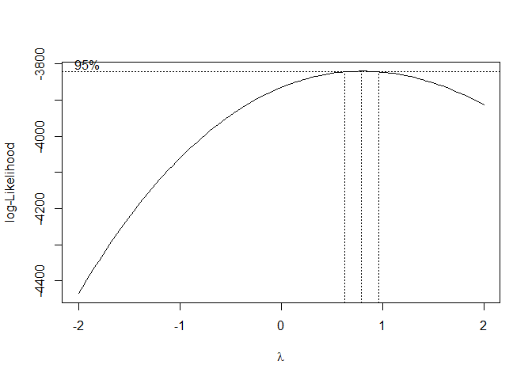

```r
library(MASS)
boxcox(mrls)
#boxcox(mrls,lambda = seq(0, 2, by = 1/10))

bc<-boxcox(mrls)
```

```r
(lambda <- bc$x[which.max(bc$y)])
```

```
[1] 0.7878788
```

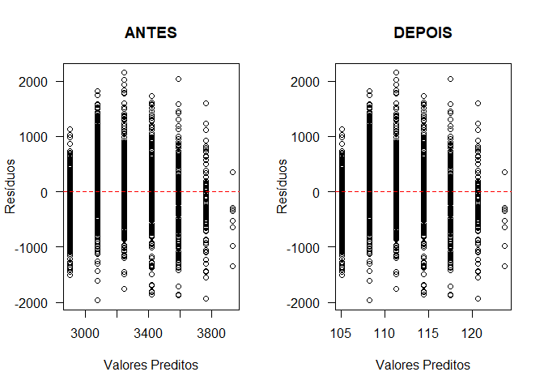

```r
#Aplicação da transformação boxcox em Y
banco$y<- (banco$milk120^(0.5) - 1)/0.5

#Ajuste do modelo com variável transformada
mrls1<-lm(banco$y~banco$parity)


#comparação do gráfico predito vs resíduos antes e depois da transformação
par(mfrow=c(1,2))
plot(mrls$fitted.values,mrls$residuals,xlab="Valores Preditos",ylab="Resíduos",main="ANTES", las=1)
abline(h=0, lwd=1, lty=2, col="red")

plot(mrls1$fitted.values,mrls$residuals,xlab="Valores Preditos",ylab="Resíduos",main="DEPOIS", las=1)
abline(h=0, lwd=1, lty=2, col="red")
```

```r
#Teste de Breusch-Pagan
bptest(mrls1)
```

```
    studentized Breusch-Pagan test

data:  mrls1
BP = 0.31652, df = 1, p-value = 0.5737
```